# 219000429_GY7708_CW2

```r
library(tidyverse)
library(tidytext)
library(magrittr)
library(jsonlite)
library(httr)
library(rvest)
library(htm2txt)
library(stringi)
library(WikipediR)
library(dplyr)
library(tm)
library(tokenizers)
library(sf)
library(raster)
library(cluster)
library(textdata)
library(wordcloud)
library(reshape2)
```

#Part-1

Using the csv file wikipedia_geotags_in_uk the data set are loaded into wiki_geo. It contains the list of geotags associated with the wikipedia articles.

```r
wiki_geo <- read.csv(file.choose())
```

The Local Authority District (LAD) assigned for the coursework is Wealden which contains 267 articles. From Wiki_geo Wealden LAD is filtered

```r
wiki_geo <- wiki_geo %>%
  filter(LAD21NM == 'Wealden') %>%
  filter(gt_primary == 1)
```

The code given by Stefano De Saddata in the coursework is modified and used to retrieve all the page summaries present in the given LAD.

```r
page_sent <- data.frame(
  page_name = character(),
  a_page_summary = character()
)

for ( a_page_title in wiki_geo$page_title){
# Retrieve the summary
a_page_summary <-
  httr::GET(
    # Base API URL
    url = "https://en.wikipedia.org/w/api.php",
    # API query definition
    query = list(
      # Use JSON data format
      format = "json",
      action = "query",
      # Only retrieve the intro
      prop = "extracts",
      exintro = 1,
      explaintext = 1,
      redirects = 1,
      # Set the title
      titles = a_page_title
    )
  ) %>%
  # Get the content
  httr::content(
    as = "text",
    encoding = "UTF-8"
  ) %>%
  # Trasnform JSON content to R list
  jsonlite::fromJSON() %>%
  # Extract the summary from the list
  magrittr::extract2("query") %>%
  magrittr::extract2("pages") %>%
  magrittr::extract2(1) %>%
  magrittr::extract2("extract")

a_page_summary <- as.data.frame(a_page_summary)
a_page_summary$page_name <- a_page_title
print (a_page_summary)
page_sent <- page_sent %>%
  add_row(a_page_summary)
}
```

| a_page_summary | page_name |
| --- | --- |
| Maynard's Green is a village in the Wealden district of East Sussex.\n\n | Maynard's_Green |

| a_page_summary | page_name |
| --- | --- |
| High Hurstwood is a village in the Wealden district of East Sussex. | High_Hurstwood |

| a_page_summary | page_name |
| --- | --- |
| Magham Down is a village between Herstmonceux and Hailsham in the Wealden district of East Sussex. It lies on the A271 road. It has a Grade II listed building, Magham Down Manor House. \n\nHistoricall… | Magham_Down |

| a_page_summary | page_name |
| --- | --- |
| Heron's Ghyll is a hamlet in the Wealden district of East Sussex. St John the Evangelist Church is a Catholic church in the village. There is a late 19th-century garden laid out by the poet Coventry P… | Heron's_Ghyll |

| a_page_summary | page_name |
| --- | --- |
| Windmill Hill is a village in the Wealden district of East Sussex. | Windmill_Hill,_East_Sussex |

| a_page_summary | page_name |
| --- | --- |
| The River Grom is a short tributary of the River Medway near Tunbridge Wells in south-east England. Flowing westwards through High Rocks and Groombridge, it forms the Kent-Sussex border for part of it… | River_Grom |

| a_page_summary | page_name |
| --- | --- |
| Roser's Cross is a village in the Wealden district of East Sussex. | Roser's_Cross |

| a_page_summary | page_name |
| --- | --- |
| Hooe Common is a village in the Wealden district of East Sussex. | Hooe_Common |

| a_page_summary | page_name |
| --- | --- |
| Vines Cross is a village in the Wealden district of East Sussex, England. | Vines_Cross |

| a_page_summary | page_name |
| --- | --- |
| Buckwell Place is a Grade II* listed country house in Herstmonceux, East Sussex, England. A former rectory, the original wing of the house was built in 1792 by Reverend Robert Hare, whose family owned… | Buckwell_Place |

| a_page_summary | page_name |
| --- | --- |
| St Dunstan's Farm Meadows is a 10.2-hectare (25-acre) biological Site of Special Scientific Interest south-east of Heathfield in East Sussex. It is in the High Weald Area of Outstanding Natural Beauty… | St_Dunstan's_Farm_Meadows |

| a_page_summary | page_name |
| --- | --- |
| Mills Rocks is a 1.9-hectare (4.7-acre) biological Site of Special Scientific Interest south-east of East Grinstead in West Sussex.This site has rock outcrops with a number of rare plants, such as ree… | Mills_Rocks |

| a_page_summary | page_name |
| --- | --- |
| Ashdown Forest is an ancient area of open heathland occupying the highest sandy ridge-top of the High Weald Area of Outstanding Natural Beauty. It is situated some 30 miles (48 km) south of London in … | Ashdown_Forest_Llama_Park |

| a_page_summary | page_name |
| --- | --- |
| Crowborough Country Park is a 7.3-hectare (18-acre) Local Nature Reserve on the western outskirts of Crowborough in East Sussex. It is owned and managed by Crowborough Town Council.The park has divers… | Crowborough_Country_Park |

| a_page_summary | page_name |
| --- | --- |
| Old Lodge is a 103.1-hectare (255-acre) Local Nature Reserve west of Crowborough in East Sussex. It is privately owned. It is managed by Sussex Wildlife Trust. It is part of Ashdown Forest, which is a… | Old_Lodge |

| a_page_summary | page_name |
| --- | --- |
| West Park is a 10.5-hectare (26-acre) Local Nature Reserve on the western outskirts of Uckfield in East Sussex. It is owned and managed by Uckfield Town Council.This site has grassland, woodland and a… | West_Park,_Uckfield |

| a_page_summary | page_name |
| --- | --- |
| Hempstead Meadow is a 1.6-hectare (4.0-acre) Local Nature Reserve in Uckfield in East Sussex. It is owned and managed by Uckfield Town Council.The site is mainly wet grassland with scattered trees and… | Hempstead_Meadow |

| a_page_summary | page_name |
| --- | --- |
| Brickfield Meadow is a 1.4-hectare (3.5-acre) nature reserve north of Maresfield in East Sussex. It is managed by the Sussex Wildlife Trust.This wildflower rich meadow has been traditionally managed f… | Brickfield_Meadow |

| a_page_summary | page_name |
| --- | --- |
| Selwyns Wood is a 11-hectare (27-acre) nature reserve west of Heathfield in Sussex. It is managed by the Sussex Wildlife Trust.This reserve has woodland with extensive sweet chestnut, a stream in a na… | Selwyns_Wood |

| a_page_summary | page_name |
| --- | --- |
| Folkington Manor (pronounced Fo'ington) is a grade II listed country house situated in the hamlet of Folkington two miles (3.2 km) west of Polegate, East Sussex, England. | Folkington_Manor |

| a_page_summary | page_name |
| --- | --- |
| The Seven Sisters Sheep Centre is a farm near East Dean, in the Seven Sisters Country Park of the South Downs. It holds a large collection of about 50 sheep breeds, including rare breeds no longer rai… | Seven_Sisters_Sheep_Centre |

| a_page_summary | page_name |
| --- | --- |
| Broad Oak is a small village near the town of Heathfield, East Sussex, England, often referred to as Broad Oak Heathfield, as there is a village with the same name, also in East Sussex, near to Brede.… | Broad_Oak_(Heathfield),_East_Sussex |

| a_page_summary | page_name |
| --- | --- |
| Blackham is a village in the Wealden district of East Sussex. It lies within the Withyham civil parish. Its nearest town is Royal Tunbridge Wells, which lies approximately 5.3 miles (8.5 km) east from… | Blackham |

| a_page_summary | page_name |
| --- | --- |
| Best Beech Hill is a locality in the civil parish of Wadhurst in the Wealden district of East Sussex, England. Wadhurst lies approximately 1.6 miles (2.6 km) north-east on the B2100 road. | Best_Beech_Hill |

| a_page_summary | page_name |
| --- | --- |
| Bodle Street Green is a small village in the civil parish of Warbleton, in the Wealden district of East Sussex, England. Its nearest town is Hailsham, which lies approximately 5 miles (8.0 km) south-w… | Bodle_Street_Green |

| a_page_summary | page_name |
| --- | --- |
| Boreham Street is a small village in the Wealden district of East Sussex, England. Its nearest towns are Hailsham, which lies approximately 6 miles (9.7 km) west of the village and Battle, which lies … | Boreham_Street |

| a_page_summary | page_name |
| --- | --- |
| Cooper's Green is a village in the civil parish of Maresfield in the Wealden district of East Sussex, England. Its nearest town is Uckfield, which lies approximately 1.3 miles (2.1 km) south-west from… | Cooper's_Green |

| a_page_summary | page_name |
| --- | --- |
| Cowbeech is a small village in the civil parish of Herstmonceux in the Wealden district of East Sussex, England. Its nearest town is Hailsham, which lies approximately 3.8 miles (6.1 km) south-west fr… | Cowbeech |

| a_page_summary | page_name |
| --- | --- |
| Etchingwood is a small cluster of mostly detached properties and farms within the civil parish of Buxted in the Wealden district of East Sussex, England. Its nearest town is Uckfield, which lies appro… | Etchingwood |

| a_page_summary | page_name |
| --- | --- |
| Fairwarp is a small village within the civil parish of Maresfield in the Wealden district of East Sussex, England. Its nearest town is Uckfield, which lies approximately 3.3 miles (5.3 km) south from … | Fairwarp |

| a_page_summary | page_name |
| --- | --- |
| Five Ash Down is a small village within the civil parish of Maresfield in the Wealden district of East Sussex, England. Its nearest town is Uckfield, which lies approximately 1.8 miles (2.9 km) south … | Five_Ash_Down |

| a_page_summary | page_name |
| --- | --- |
| Golden Cross is a small village in the Wealden district of East Sussex, England. Its nearest town is Hailsham, which lies approximately 3.6 miles (5.8 km) south-east from the village. The village lies… | Golden_Cross,_East_Sussex |

| a_page_summary | page_name |
| --- | --- |
| Gun Hill is a hamlet in the civil parish of Chiddingly in the Wealden district of East Sussex, England. It is one of the seven hills of the parish in which it stands. Its nearest town is Uckfield, whi… | Gun_Hill,_East_Sussex |

| a_page_summary | page_name |
| --- | --- |
| Rushlake Green is a small village in the civil parish of Warbleton in the Wealden district of East Sussex, England. Rushlake Green is situated on the slopes of the Weald between Heathfield 4 miles (6.… | Rushlake_Green |

| a_page_summary | page_name |
| --- | --- |
| Bingletts Wood is a 16-hectare (40-acre) biological Site of Special Scientific Interest east of Heathfield in East Sussex.Part of this ancient wood is a steep sided valley which has a warm and moist m… | Bingletts_Wood |

| a_page_summary | page_name |
| --- | --- |
| Bream Wood is a 7.8-hectare (19-acre) biological Site of Special Scientific Interest north of Crowborough in East Sussex.This steep sided valley wood has several locally rare ferns and mosses. There a… | Bream_Wood |

| a_page_summary | page_name |
| --- | --- |
| Milton Gate Marsh is a 17.7-hectare (44-acre) biological Site of Special Scientific Interest north-west of Eastbourne in East Sussex.This site consists of two areas of alluvial wetland in the valleys … | Milton_Gate_Marsh |

| a_page_summary | page_name |
| --- | --- |
| Rock Wood is a 10.4-hectare (26-acre) biological Site of Special Scientific Interest north of Uckfield in East Sussex.This ancient wood has several different types of broadleaved woodland, a stream wh… | Rock_Wood |

| a_page_summary | page_name |
| --- | --- |
| Burgh Hill Farm Meadow is a 0.9-hectare (2.2-acre) biological Site of Special Scientific Interest west of Hailsham in East Sussex.This meadow is managed to encourage wildlife and 67 species of floweri… | Burgh_Hill_Farm_Meadow |

| a_page_summary | page_name |
| --- | --- |
| Jarvis Brook is a village between Crowborough and Rotherfield in the Borough of WealdenEast Sussex. Jarvis Brook is home to Crowborough Railway Station on the Uckfield branch of the Oxted Line.\n\n | Jarvis_Brook |

| a_page_summary | page_name |
| --- | --- |
| Sheffield Park is a cricket ground at the Sheffield Park estate, located near Uckfield, East Sussex, England. From 1881 to 1896 it was the home ground of Lord Sheffield's XI, organised by Henry Holroy… | Sheffield_Park_cricket_ground |

| a_page_summary | page_name |
| --- | --- |
| Ashdown Forest, a former royal hunting forest situated some 30 miles south-east of London, is a large area of lowland heathland whose ecological importance has been recognised by its designation as a … | Landscape_of_Ashdown_Forest |

| a_page_summary | page_name |
| --- | --- |
| Duddleswell is a village in the Wealden district, East Sussex in England, United Kingdom. | Duddleswell |

| a_page_summary | page_name |
| --- | --- |
| Bowles Outdoor Centre is an outdoor education/outdoor learning centre in southeast England, located between Tunbridge Wells and Crowborough at Bowles Rocks. The centre was founded in 1961 and became a… | Bowles_Outdoor_Centre |

| a_page_summary | page_name |
| --- | --- |
| Piltdown is a series of hamlets in East Sussex, England. It is located south of Ashdown Forest. It is best known for the Piltdown Man hoax where amateur archaeologist Charles Dawson claimed to have di… | Piltdown |

| a_page_summary | page_name |
| --- | --- |
| Emerson College was founded in 1962 by Francis Edmunds. It is now situated on Pixton Hill, Forest Row in East Sussex, UK. It was named after Ralph Waldo Emerson, American poet and transcendentalist. F… | Emerson_College_(UK) |

| a_page_summary | page_name |
| --- | --- |
| Wootton Manor is a country house in Folkington, East Sussex. Originally a mediaeval manor house, from which parts of the chapel survive, it was rebuilt in the mid-17th century in a rather old-fashione… | Wootton_Manor |

| a_page_summary | page_name |
| --- | --- |
| Wych Cross is a location in Ashdown Forest, in the Wealden district of East Sussex. It lies on the sandstone forest ridge of the High Weald on the principal road from London to the east Sussex county … | Wych_Cross |

| a_page_summary | page_name |
| --- | --- |
| Chelwood Gate is a small village within the civil parish of Danehill in the Wealden district of East Sussex, England. Its nearest town is Uckfield, which lies approximately 6.6 miles (10.6 km) south-e… | Chelwood_Gate |

| a_page_summary | page_name |
| --- | --- |
| Buckhurst Park is an English country house and landscaped park in Withyham, East Sussex. It is the seat of William Sackville, 11th Earl De La Warr.\nThe house is a Grade II listed building, and is ope… | Buckhurst_Park,_Sussex |

| a_page_summary | page_name |
| --- | --- |
| Horsted Place is a Tudor Revival country house, now a hotel, in Little Horsted, East Sussex, England. The current building dates to 1850, when it was built by Samuel Daukes/George Myers for Francis Ba… | Horsted_Place |

| a_page_summary | page_name |
| --- | --- |
| Copping Hall is a Grade II* listed house in Uckfield, East Sussex, England. It is located at 1 Pudding Cake Lane, Uckfield, East Sussex TN22 1BT. Built in the eighteenth century, it is two-storey high… | Copping_Hall |

| a_page_summary | page_name |
| --- | --- |
| Herstmonceux Place is an 18th-century country house in Herstmonceux, East Sussex. It was divided into apartments in the 1950s. The house stands within a 148 hectares (370 acres) shared estate with Her… | Herstmonceux_Place |

| a_page_summary | page_name |
| --- | --- |
| Cotchford Farm is a farmhouse building to the southwest of the village of Hartfield, East Sussex, in the High Weald Area of Outstanding Natural Beauty, in southern England. The building stands on Cotc… | Cotchford_Farm |

| a_page_summary | page_name |
| --- | --- |
| Heathfield Park SSSI is a 41-hectare (100-acre) biological Site of Special Scientific Interest east of Heathfield in East Sussex. It is part of Heathfield Park, a Grade II* listed building and park.\n… | Heathfield_Park_SSSI |

| a_page_summary | page_name |
| --- | --- |
| Punnett's Town is a village in the Wealden district of East Sussex. The main street is Battle road, which is part of the B2096 road. \n\n Blackdown Mill is a grade II listed smock mill which has been … | Punnett's_Town |

| a_page_summary | page_name |
| --- | --- |
| St Alban's Church is a Church of England parish church in Frant, East Sussex, England. It was built in 1819–22 in a fifteenth-century gothic revival style and is a grade II listed building. | St_Alban's_Church,_Frant |

| a_page_summary | page_name |
| --- | --- |
| The Church of St Margaret the Queen is a grade I listed building in Buxted Park, East Sussex, England. It is dedicated to Saint Margaret of Scotland, an 11th-century Scottish queen. The church dates f… | St_Margaret_the_Queen,_Buxted |

| a_page_summary | page_name |
| --- | --- |
| Southern Sandstone is a local name for the Ardingly Sandstone of southeast England, a soft sandstone of Cretaceous age separating the Tunbridge Wells Sands from the overlying Grinstead Clay. The outcr… | Southern_Sandstone |

| a_page_summary | page_name |
| --- | --- |
| East Dean and Friston is a civil parish in the Wealden District of East Sussex, England.The two villages in the parish are in a dry valley on the South Downs – between Eastbourne three miles (4.8 km) … | East_Dean_and_Friston |

| a_page_summary | page_name |
| --- | --- |
| Mayfield and Five Ashes is a civil parish in the High Weald of East Sussex, England. The two villages making up the principal part of the parish lie on the A267 road between Royal Tunbridge Wells and … | Mayfield_and_Five_Ashes |

| a_page_summary | page_name |
| --- | --- |
| Bayham Old Abbey is an English Heritage property, located near Lamberhurst, Kent, England. Founded c. 1207 through a combination of the failing Premonstratensian monasteries of Otham and Brockley, Bay… | Bayham_Old_Abbey |

| a_page_summary | page_name |
| --- | --- |
| Weir Wood Reservoir is a 153.5-hectare (379-acre) biological Site of Special Scientific Interest west of Forest Row in East Sussex. It is in High Weald Area of Outstanding Natural Beauty and an area o… | Weir_Wood_Reservoir |

| a_page_summary | page_name |
| --- | --- |
| Harrison's Rocks is a sandstone crag approximately 1.5 kilometres (1 mi) south of the village of Groombridge in the county of East Sussex. The site is a notable example of a periglacial tor landform d… | Harrison's_Rocks |

| a_page_summary | page_name |
| --- | --- |
| Pevensey Levels is a 3,603.2-hectare (8,904-acre) biological Site of Special Scientific Interest between Bexhill-on-Sea and Hailsham in East Sussex. It is a Nature Conservation Review site, Grade I, a… | Pevensey_Levels |

| a_page_summary | page_name |
| --- | --- |
| Cross-in-Hand is a small village outside Heathfield town to its west, in the Wealden District situated in East Sussex. It is occasionally referred to as Isenhurst. | Cross_In_Hand |

| a_page_summary | page_name |
| --- | --- |
| Arlington Reservoir is a 100.4-hectare (248-acre) biological Site of Special Scientific Interest west of Hailsham in East Sussex. It is also a Local Nature Reserve and it is owned and managed by South… | Arlington_Reservoir |

| a_page_summary | page_name |
| --- | --- |
| High Rocks is a 3.2-hectare (7.9-acre) geological Site of Special Scientific Interest west of Tunbridge Wells in East Sussex and Kent. It is a Geological Conservation Review site. | High_Rocks |

| a_page_summary | page_name |
| --- | --- |
| Lower Dicker is a 0.1-hectare (0.25-acre) geological Site of Special Scientific Interest west of Hailsham in East Sussex. It is a Geological Conservation Review site.\n\n | Lower_Dicker |

| a_page_summary | page_name |
| --- | --- |
| Folkington Reservoir is a 5.8-hectare (14-acre) biological Site of Special Scientific Interest south-west of Polegate in East Sussex.The banks of the reservoir support a rich chalk grassland flora inc… | Folkington_Reservoir |

| a_page_summary | page_name |
| --- | --- |
| Penn's Rocks is a 10.2-hectare (25-acre) biological Site of Special Scientific Interest north of Crowborough in East Sussex.This site is a steep sided valley on sandstone with many mosses and liverwor… | Penn's_Rocks |

| a_page_summary | page_name |
| --- | --- |
| Park Corner Heath is a 2.9-hectare (7.2-acre) biological Site of Special Scientific Interest about 1.2 miles (2 km) south of East Hoathly, adjacent to the A22 main road between Uckfield and Eastbourne… | Park_Corner_Heath |

| a_page_summary | page_name |
| --- | --- |
| Hastingford Cutting is a 0.04-hectare (0.099-acre) geological Site of Special Scientific Interest south of Crowborough in East Sussex. It is a Geological Conservation Review site.This site exposes roc… | Hastingford_Cutting |

| a_page_summary | page_name |
| --- | --- |
| Sapperton Meadows is a 14.7-hectare (36-acre) biological Site of Special Scientific Interest south of Heathfield in East Sussex.These poorly drained hay meadows and rich pastures are managed by tradit… | Sapperton_Meadows |

| a_page_summary | page_name |
| --- | --- |
| Paines Cross Meadow is a 3.7-hectare (9.1-acre) biological Site of Special Scientific Interest north-east of Heathfield in East Sussex.This site is damp meadow on heavy clay with some areas of peat ar… | Paines_Cross_Meadow |

| a_page_summary | page_name |
| --- | --- |
| Stockland Farm Meadows is a 5.8-hectare (14-acre) biological Site of Special Scientific Interest south of Crowborough in East Sussex.These two species rich meadows are traditionally managed. Over 80 s… | Stockland_Farm_Meadows |

| a_page_summary | page_name |
| --- | --- |
| Waldron Cutting is a 0.2-hectare (0.49-acre) geological Site of Special Scientific Interest in East Sussex. It is a Geological Conservation Review site.This site exposes siltstones and fine sandstone … | Waldron_Cutting |

| a_page_summary | page_name |
| --- | --- |
| Eridge Green is a 8.4-hectare (21-acre) biological Site of Special Scientific Interest north-east of Crowborough in East Sussex. It is part of the 44 hectares (110 acres) Eridge Rocks nature reserve, … | Eridge_Green |

| a_page_summary | page_name |
| --- | --- |
| Herstmonceux Park is a 4.3-hectare (11-acre) biological Site of Special Scientific Interest south of Herstmonceux in East Sussex.This narrow stream valley has seven examples of wetland habitats on Tun… | Herstmonceux_Park |

| a_page_summary | page_name |
| --- | --- |
| Seaford to Beachy Head is a 1,108.7-hectare (2,740-acre) biological and geological Site of Special Scientific Interest which stretches from Seaford to Eastbourne in East Sussex. It has several Geologi… | Seaford_to_Beachy_Head |

| a_page_summary | page_name |
| --- | --- |
| Wilmington Downs is a 209.8-hectare (518-acre) biological Site of Special Scientific Interest north-west of Eastbourne in East Sussex. The site includes a Scheduled Monument, the Long Man of Wilmingto… | Wilmington_Downs |

| a_page_summary | page_name |
| --- | --- |
| Lullington Heath is a 72.7-hectare (180-acre) biological Site of Special Scientific Interest west of Eastbourne in East Sussex. It is a national nature reserve and a Nature Conservation Review site, G… | Lullington_Heath |

| a_page_summary | page_name |
| --- | --- |
| Local Nature Reserves (LNRs) are designated by local authorities under the National Parks and Access to the Countryside Act 1949. The local authority must have a legal control over the site, by owning… | List_of_local_nature_reserves_in_East_Sussex |

| a_page_summary | page_name |
| --- | --- |
| Warbleton Priory was a medieval monastic house in East Sussex, England.\n\n | Warbleton_Priory |

| a_page_summary | page_name |
| --- | --- |
| Isaac Roberts' Observatory was an observatory, installed in the private home of the British astronomer Isaac Roberts. It was in Crowborough, Sussex, and was active from 1890, when Roberts installed it… | Isaac_Roberts'_Observatory |

| a_page_summary | page_name |
| --- | --- |
| Bowles Rocks is a sandstone crag in the county of East Sussex, on the border with Kent, approximately 8 kilometres (5 mi) south of the town of Tunbridge Wells. It is popular with rock climbers due to … | Bowles_Rocks |

| a_page_summary | page_name |
| --- | --- |
| Otham Abbey was a medieval monastic house in Polegate, East Sussex, England.\n\n | Otham_Abbey |

| a_page_summary | page_name |
| --- | --- |
| England's Medieval Festival is a medieval-themed festival held over the August bank holiday at Herstmonceux Castle in Sussex, England. Held over three days, the festival features jousting, falconry, k… | England's_Medieval_Festival |

| a_page_summary | page_name |
| --- | --- |
| Laughton Place is a historic building near Lewes, Sussex owned by the Landmark Trust. The Pelham family bought Laughton Place, an old fortified manor, in 1466; it was rebuilt in 1534 by William Pelham… | Laughton_Place |

| a_page_summary | page_name |
| --- | --- |
| Temple Grove School was a preparatory school for boys, and after 1984 also for girls, originally at Parsons Green, London, later at East Sheen, London, still later at Eastbourne, and finally at Heron'… | Temple_Grove_School |

| a_page_summary | page_name |
| --- | --- |
| Tidebrook is a hamlet within the parish of Wadhurst in East Sussex, England. It is located between the villages of Mayfield and Wadhurst. The brook for which the hamlet is named rises in the valley an… | Tidebrook |

| a_page_summary | page_name |
| --- | --- |
| The Rehoboth Chapel is a Strict Baptist place of worship in the village of Jarvis Brook in the English county of East Sussex.\nThe red- and blue-brick building dates from 1876. Its Gospel Standard Str… | Rehoboth_Chapel,_Jarvis_Brook |

| a_page_summary | page_name |
| --- | --- |
| Heathfield and Waldron is a civil parish within the Wealden District of East Sussex, England. Heathfield is surrounded by the High Weald Area of Outstanding Natural Beauty.\n\n | Heathfield_and_Waldron |

| a_page_summary | page_name |
| --- | --- |
| Buxted Park is an 84.7 hectare (206.16 acre) biological Site of Special Scientific Interest, located near the village of Buxted, East Sussex, England. The main house is just over 0.5 km northeast of t… | Buxted_Park |

| a_page_summary | page_name |
| --- | --- |
| Aspidistra was a British medium wave radio transmitter used for black propaganda and military deception purposes against Nazi Germany during World War II. At times in its history it was the most power… | Aspidistra_(transmitter) |

| a_page_summary | page_name |
| --- | --- |
| The Cuckoo Trail is a 14-mile (23 km) footpath and cycleway which runs from Hampden Park to Heathfield in East Sussex. It passes through the towns of Polegate and Hailsham, as well as the villages of … | Cuckoo_Trail |

| a_page_summary | page_name |
| --- | --- |
| The Vanguard Way is a long-distance walk of 66.2 mi (106.5 km) from East Croydon station in outer London (OS grid reference TQ328658), travelling from the north, to Newhaven, on the south coast of Eng… | Vanguard_Way |

| a_page_summary | page_name |
| --- | --- |
| Lullington Church, also known as the Church of the Good Shepherd, on the South Downs at Lullington in East Sussex is one of several churches claimed to be the smallest church in England. It was built … | Lullington_Church |

| a_page_summary | page_name |
| --- | --- |
| A.F.C. Uckfield Town is a football club based in Uckfield, East Sussex, England. They are currently members of the Southern Combination Premier Division and play at The Oaks. | A.F.C._Uckfield_Town |

| a_page_summary | page_name |
| --- | --- |
| Uckfield Town F.C. was a football club based in Uckfield, East Sussex, England. For their final season, 2013–14, they were members of the Sussex County League (since re-named Southern Combination Leag… | Uckfield_Town_F.C. |

| a_page_summary | page_name |
| --- | --- |
| The Great Bush Railway is a private, 2 ft (610 mm) narrow gauge running round the edge of Tinkers Park, Hadlow Down, Sussex. The railway is operated by the Claude Jessett Trust Company.\nThe line is 5… | Great_Bush_Railway |

| a_page_summary | page_name |
| --- | --- |
| Pevensey Castle is a medieval castle and former Roman Saxon Shore fort at Pevensey in the English county of East Sussex. The site is a scheduled monument in the care of English Heritage and is open to… | Pevensey_Castle |

| a_page_summary | page_name |
| --- | --- |
| The 1066 Country Walk is a waymarked long-distance footpath or recreational walk in southern England, United Kingdom.\n\n | 1066_Country_Walk |

| a_page_summary | page_name |
| --- | --- |
| RAF Wartling was a Royal Air Force station located near the village of Wartling in East Sussex. It was a Second World War and later Cold War Ground Controlled Interception (GCI) station built to compl… | RAF_Wartling |

| a_page_summary | page_name |
| --- | --- |
| Firle Hill Climb is a defunct hillclimbing course near Lewes, East Sussex, England, sometimes referred to as Bo Peep Hill Climb. The event was celebrated on 20 September 2015 by the Bo Peep Drivers Cl… | Firle_Hill_Climb |

| a_page_summary | page_name |
| --- | --- |
| Ashdown Radio is a community radio station in East Sussex, broadcasting from transmitters in Uckfield and Crowborough. It is owned by Ashdown Radio Limited.\nThe station began as Uckfield FM in 2003 a… | Uckfield_FM |

| a_page_summary | page_name |
| --- | --- |
| The Out of the Ordinary Festival was an annual family- and eco-friendly music festival near Hailsham in the Sussex countryside. From 2007 to 2013 it celebrated the autumn equinox in England with a var… | Out_of_the_Ordinary_Festival |

| a_page_summary | page_name |
| --- | --- |
| The Bolebroke Castle Miniature Railway or Bolebroke Castle and Lakes Railway (often abbreviated to BC&LR) was a 7+1/4 inches (180 mm) railway that ran within the grounds of Bolebroke Castle. The railw… | Bolebroke_Castle_Miniature_Railway |

| a_page_summary | page_name |
| --- | --- |
| Farleys House near Chiddingly, East Sussex, has been converted into a museum and archive featuring the lives and work of its former residents, the photographer Lee Miller and the Surrealist artist Rol… | Farleys_House |

| a_page_summary | page_name |
| --- | --- |
| The Bentley Wildfowl and Motor Museum was a visitor attraction in Halland, East Sussex, England. As of October 2018, it is closed to the public. | Bentley_Wildfowl_and_Motor_Museum |

| a_page_summary | page_name |
| --- | --- |
| Bassetts Manor is a Grade II-listed building in Hartfield, East Sussex, England.\n\n | Bassetts_Manor |

| a_page_summary | page_name |
| --- | --- |
| Luxford House is a 16th-century Grade II listed building near Crowborough, East Sussex. It is near the 11.5-acre (4.7 ha) Luxford Farm. It was used by several rock musicians in the 1970s under the gui… | Luxford_House |

| a_page_summary | page_name |
| --- | --- |
| Wadhurst Castle is a 19th-century castellated mansion just to the west of the town of Wadhurst, East Sussex, England, in an elevated position overlooking the countryside to the south. It is a grade II… | Wadhurst_Castle |

| a_page_summary | page_name |
| --- | --- |
| Magham Down Manor House is a Grade II listed building in Magham Down in the Wealden district of East Sussex.\n\n | Magham_Down_Manor_House |

| a_page_summary | page_name |
| --- | --- |
| Dean’s Place in Alfriston, Sussex is a building of historical significance and is listed on the English Heritage Register. It was built in the 17th century or earlier and was the residence of several … | Dean's_Place_Hotel,_Alfriston |

| a_page_summary | page_name |
| --- | --- |
| Association Football Club Uckfield was a football club based in Uckfield, East Sussex, England. | A.F.C._Uckfield |

| a_page_summary | page_name |
| --- | --- |
| The Byline Festival is a festival whose aim is to promote independent journalism and free speech. The festival was founded by Stephen Colegrave and Peter Jukes in 2017. Its tagline is "Dance, Discuss,… | Byline_Festival |

| a_page_summary | page_name |
| --- | --- |
| Poundgate is a hamlet in East Sussex on the A26 Uckfield Road at the junction with Chillies Road, just south of Crowborough. It has one pub, the Crow and Gate, on the main road and a scattering of mai… | Poundgate |

| a_page_summary | page_name |
| --- | --- |
| Wilmington Priory was a Benedictine priory in the civil parish of Long Man, East Sussex, England. The surviving building is now owned by the Landmark Trust and let as holiday accommodation. It is both… | Wilmington_Priory |

| a_page_summary | page_name |
| --- | --- |
| Furner's Green is a hamlet in the civil parish of Danehill in East Sussex, England. | Furner's_Green |

| a_page_summary | page_name |
| --- | --- |
| Framfield is a village and civil parish in the Wealden District of East Sussex, England. The village is located two miles (3 km) east of Uckfield; the settlements of Blackboys, Palehouse and Halland f… | Framfield |

| a_page_summary | page_name |
| --- | --- |
| Lieutenant Richard Frank Hill (28 April 1899 – 17 September 1918) was a British World War I flying ace credited with seven aerial victories. | Richard_Hill_(RAF_officer) |

| a_page_summary | page_name |
| --- | --- |
| Captain Oliver Manners Sutton (12 March 1896 – 16 August 1921) was a British First World War flying ace credited with seven aerial victories. | Oliver_Sutton_(RAF_officer) |

| a_page_summary | page_name |
| --- | --- |
| Bolebroke Castle is a 15th-century hunting lodge located north of the village of Hartfield, East Sussex, England. It is a grade II* listed building.The house was built around 1480. Henry VIII is said … | Bolebroke_Castle |

| a_page_summary | page_name |
| --- | --- |
| Danehill is a village in East Sussex, England. | Danehill,_East_Sussex |

| a_page_summary | page_name |
| --- | --- |
| Buxted is a village and civil parish in the Wealden District of East Sussex in England. The parish is situated on the Weald, north of Uckfield; the settlements of Five Ash Down, Heron's Ghyll and High… | Buxted |

| a_page_summary | page_name |
| --- | --- |
| Hooe is both a small village and a civil parish in the Wealden District of East Sussex; the village being located about two miles (3 km) north-west of Bexhill, and north of the A259 coast road, on the… | Hooe,_East_Sussex |

| a_page_summary | page_name |
| --- | --- |
| Jameah Islameah School was an independent Islamic school in East Sussex. The school was located on a 54 acre site and had residential facilities to house male students aged 11 to 16. The school was in… | Jameah_Islameah_School |

| a_page_summary | page_name |
| --- | --- |
| Forest Row is a village and a large civil parish in the Wealden District of East Sussex, England. The village is located three miles (5 km) south-east of East Grinstead. | Forest_Row |

| a_page_summary | page_name |
| --- | --- |
| Alciston is a village and civil parish in the Wealden district of East Sussex, England. It is inland, just off the A27 road, about ten miles (16 km) north-west of Eastbourne and seven miles (11 km) ea… | Alciston |

| a_page_summary | page_name |
| --- | --- |
| Arlington is a village and civil parish in the Wealden district of East Sussex, England. The parish is on the River Cuckmere, and is the location for a medieval priory, a reservoir and car racetrack. | Arlington,_East_Sussex |

| a_page_summary | page_name |
| --- | --- |
| Fletching is a village and civil parish in the Wealden District of East Sussex, England. It is located three miles (4.8 km) to the north-west of Uckfield, near one of the entrances to Sheffield Park. … | Fletching,_East_Sussex |

| a_page_summary | page_name |
| --- | --- |
| Laughton is a village and civil parish in the Wealden District of East Sussex, England. The village is located five miles (8 km) east of Lewes, at a junction on the minor road to Hailsham (B2124). It … | Laughton,_East_Sussex |

| a_page_summary | page_name |
| --- | --- |
| Hellingly (pronounced 'Helling-lye') is a village, and can also refer to a civil parish, and to a district ward, in the Wealden District of East Sussex, England. | Hellingly |

| a_page_summary | page_name |
| --- | --- |
| Little Horsted (also known as Horsted Parva) is a village and civil parish in the Wealden District of East Sussex, England. It is located two miles (3.2 km) south of Uckfield, on the A26 road.\nThe vi… | Little_Horsted |

| a_page_summary | page_name |
| --- | --- |
| Frant is a village and civil parish in the Wealden District of East Sussex, England, on the Kentish border about three miles (5 km) south of Royal Tunbridge Wells.\nWhen the iron industry was at its h… | Frant |

| a_page_summary | page_name |
| --- | --- |
| Hadlow Down is a village and civil parish in the Wealden District of East Sussex, England. It is located on the A272 road three miles (4.8 km) north-east of Heathfield. The parish is within the High W… | Hadlow_Down |

| a_page_summary | page_name |
| --- | --- |
| Selmeston is a village and civil parish in the Wealden District of East Sussex, England. It is located eight miles (13 km) east of Lewes, to the north of the A27 road between there and Polegate.\nThe … | Selmeston |

| a_page_summary | page_name |
| --- | --- |
| Warbleton is a village and civil parish in the Wealden District of East Sussex, England. Within its bounds are three other settlements. It is located south-east of Heathfield on the slopes of the Weal… | Warbleton |

| a_page_summary | page_name |
| --- | --- |
| Wartling is a village and civil parish in the Wealden District of East Sussex, England, between Bexhill and Hailsham, ten miles (16 km) west of the latter at the northern edge of the Pevensey Levels. … | Wartling |

| a_page_summary | page_name |
| --- | --- |
| Westham is a large village civil parish in the Wealden District of East Sussex, England. The village is adjacent to Pevensey five miles (8 km) north-east of Eastbourne. The parish consists of three se… | Westham |

| a_page_summary | page_name |
| --- | --- |
| Nutley is a village in the Wealden District of East Sussex, England. It lies about 5 mi (8.0 km) north-west of Uckfield, the main road being the A22. Nutley, Fairwarp and Maresfield together form the … | Nutley,_East_Sussex |

| a_page_summary | page_name |
| --- | --- |
| The River Uck is a river in East Sussex, United Kingdom, which drains a catchment starting near Crowborough in the North, Hadlow Down to the East and Laughton, East Sussex to the South. It flows throu… | River_Uck |

| a_page_summary | page_name |
| --- | --- |
| Alfriston Market Cross is the only remaining market cross in Sussex, other than the elaborate market cross in Chichester. It is formed of a stone base and shaft on a brick plinth; the cross itself is … | Alfriston_Market_Cross |

| a_page_summary | page_name |
| --- | --- |
| Anderitum (also Anderida or Anderidos) was a Saxon Shore fort in the Roman province of Britannia. The ruins adjoin the west end of the village of Pevensey in East Sussex, England. The fort was built i… | Anderitum |

| a_page_summary | page_name |
| --- | --- |
| In England, Sites of Special Scientific Interest (SSSIs) are designated by Natural England, which is responsible for protecting England's natural environment. Designation as an SSSI gives legal protec… | List_of_Sites_of_Special_Scientific_Interest_in_East_Sussex |

| a_page_summary | page_name |
| --- | --- |
| Crowborough Athletic Football Club is a football club based in Crowborough, East Sussex, England. Affiliated to the Sussex County Football Association, the club are currently members of the Southern C… | Crowborough_Athletic_F.C. |

| a_page_summary | page_name |
| --- | --- |
| The Long Man of Wilmington or Wilmington Giant is a hill figure on the steep slopes of Windover Hill near Wilmington, East Sussex, England. It is 6 miles (9.7 km) northwest of Eastbourne and 1/3 mile … | Long_Man_of_Wilmington |

| a_page_summary | page_name |
| --- | --- |
| The Heathfield transmitting station is a facility for FM and television transmission at Heathfield, East Sussex, UK (grid reference TQ566220). Opened in 1969 it uses as its antenna mast a 135 metres (… | Heathfield_transmitting_station |

| a_page_summary | page_name |
| --- | --- |
| Hartfield was a railway station serving Hartfield, England, on the Three Bridges to Tunbridge Wells Central Line which closed in 1967, a casualty of the Beeching Axe.The station opened on 1 October 18… | Hartfield_railway_station |

| a_page_summary | page_name |
| --- | --- |
| Horam railway station was on the Cuckoo Line between Hellingly and Heathfield, serving the village of Horam.\n\n | Horam_railway_station |

| a_page_summary | page_name |
| --- | --- |
| Hellingly was a railway station on the now closed Polegate to Eridge line (the Cuckoo Line) in East Sussex. It served the village of Hellingly.\n\n | Hellingly_railway_station |

| a_page_summary | page_name |
| --- | --- |
| Mayfield was a railway station on the now closed Eridge to Polegate cross country line (the Cuckoo Line). It was built by London, Brighton and South Coast Railway and closed under the Beeching Axe in … | Mayfield_railway_station |

| a_page_summary | page_name |
| --- | --- |
| Rotherfield and Mark Cross (also Rotherfield) is the name of a closed station on the Eridge - Heathfield - Polegate railway (the Cuckoo Line) in East Sussex. The station was built by London, Brighton … | Rotherfield_and_Mark_Cross_railway_station |

| a_page_summary | page_name |
| --- | --- |
| Groombridge railway station is a station on the Spa Valley Railway (SVR) in Groombridge, East Sussex, England. Once a busy station serving four directions, it closed in 1985 to British Rail services. … | Groombridge_railway_station |

| a_page_summary | page_name |
| --- | --- |
| High Rocks railway station is a station on the Spa Valley Railway in High Rocks, East Sussex, England.\nThe original High Rocks Halt opened on 1 June 1907, as part of a London, Brighton and South Coas… | High_Rocks_railway_station |

| a_page_summary | page_name |
| --- | --- |
| Hailsham Railway Station was on the Cuckoo Line between Polegate and Hellingly serving the town of Hailsham. Originally built in 1849 by the London, Brighton and South Coast Railway it was a terminus … | Hailsham_railway_station |

| a_page_summary | page_name |
| --- | --- |
| Heathfield railway station was on the Cuckoo Line between Horam and Mayfield, serving the market town of Heathfield.\nIt was opened in 1880 by London, Brighton and South Coast Railway on the line exte… | Heathfield_railway_station_(East_Sussex) |

| a_page_summary | page_name |
| --- | --- |
| Withyham was a railway station on the Three Bridges to Tunbridge Wells Central Line which closed in 1967, a casualty of the Beeching Axe. The station opened on 1 October 1866 and the buildings were de… | Withyham_railway_station |

| a_page_summary | page_name |
| --- | --- |
| Forest Row was a railway station on the Three Bridges to Tunbridge Wells Central Line which closed in 1967, a casualty of the Beeching Axe.The station opened on 1 October 1866 and the buildings were d… | Forest_Row_railway_station |

| a_page_summary | page_name |
| --- | --- |
| Isfield is a preserved railway station on the closed section of the Wealden Line which served the East Sussex village of Isfield near Uckfield. Originally opened in 1858, the station closed in 1969 an… | Isfield_railway_station |

| a_page_summary | page_name |
| --- | --- |
| The Hellingly Hospital Railway was a light railway owned and operated by East Sussex County Council, used for transporting coal and passengers to Hellingly Hospital, a psychiatric hospital near Hailsh… | Hellingly_Hospital_Railway |

| a_page_summary | page_name |
| --- | --- |
| Hailsham Town Football Club is a football club based in Hailsham, East Sussex, England. They are currently members of the Southern Combination Division One and play at the Beaconsfield. The club are k… | Hailsham_Town_F.C. |

| a_page_summary | page_name |
| --- | --- |
| Alfriston is a village and civil parish in the East Sussex district of Wealden, England. The village lies in the valley of the River Cuckmere, about four miles (6 km) north-east of Seaford and south o… | Alfriston |

| a_page_summary | page_name |
| --- | --- |
| RAF Deanland is a former Royal Air Force advanced landing ground located 4 miles (6.4 km) west of Hailsham, East Sussex and 13.4 miles (21.6 km) north east of Brighton, East Sussex, England\n\n | RAF_Deanland |

| a_page_summary | page_name |
| --- | --- |
| Wealden is a constituency represented in the House of Commons of the UK Parliament since 2015 by Nus Ghani, a Conservative. Ghani was the first Muslim woman to be elected as a Conservative member of P… | Wealden_(UK_Parliament_constituency) |

| a_page_summary | page_name |
| --- | --- |
| SM UB-121 was a German Type UB III submarine or U-boat in the German Imperial Navy (German: Kaiserliche Marine) during World War I. She was commissioned into the German Imperial Navy on 10 February 19… | SM_UB-121 |

| a_page_summary | page_name |
| --- | --- |
| Upper Hartfield is a small village slightly west of Hartfield in East Sussex, England. The Tudor house "Apedroc" in Upper Hartfield is the former home of Sir Michael Balcon. More recently the house wa… | Upper_Hartfield |

| a_page_summary | page_name |
| --- | --- |
| The Hundred Acre Wood (also spelled as 100 Aker Wood, Hundred-Acre Wood, and 100 Acre Wood; also known as simply "The Wood") is a part of the fictional land inhabited by Winnie-the-Pooh and his friend… | Hundred_Acre_Wood |

| a_page_summary | page_name |
| --- | --- |
| The Sussex Wildlife Trust (SWT) is a conservation charity which aims to protect natural life in Sussex. It was founded in 1961 and is one of 46 wildlife trusts across the UK and the Isle of Man and Al… | Sussex_Wildlife_Trust |

| a_page_summary | page_name |
| --- | --- |
| Groombridge is a village of about 1,600 people. It straddles the border between Kent and East Sussex, in England. The nearest large town is Royal Tunbridge Wells, about 4.5 miles (7.2 km) away by road… | Groombridge |

| a_page_summary | page_name |
| --- | --- |
| Ninfield is a village and civil parish in the Wealden District of East Sussex, England. The village is quite linear and centred 4 miles (6.4 km) north of Bexhill-on-Sea where two roads cross: the A269… | Ninfield |

| a_page_summary | page_name |
| --- | --- |
| The Piltdown Man was a paleoanthropological fraud in which bone fragments were presented as the fossilised remains of a previously unknown early human. Although there were doubts about its authenticit… | Piltdown_Man |

| a_page_summary | page_name |
| --- | --- |
| Royal Air Force Friston or more simply RAF Friston is a former Royal Air Force satellite station and Emergency Landing Ground located in East Sussex, England. | RAF_Friston |

| a_page_summary | page_name |
| --- | --- |
| St Andrew's Church is the parish church of Alfriston, East Sussex, England. This Grade I listed building was built in the 1370s and is also known as the 'Cathedral of the Downs'. It sits on a small, f… | St_Andrew's_Church,_Alfriston |

| a_page_summary | page_name |
| --- | --- |
| Long Burgh Long Barrow, is an unchambered long barrow located near to the village of Alfriston in the south-eastern English county of East Sussex. Probably constructed in the fourth millennium BCE, du… | Long_Burgh_Long_Barrow |

| a_page_summary | page_name |
| --- | --- |
| The Cuckoo Line is an informal name for the now defunct railway service which linked Polegate and Eridge in East Sussex, England, from 1880 to 1968. It was nicknamed the Cuckoo Line by drivers, from a… | Cuckoo_Line |

| a_page_summary | page_name |
| --- | --- |
| Uckfield Baptist Church is a Baptist congregation based in the town of Uckfield in East Sussex, England. Although services now take place in a school, the cause—founded in 1785 by seceders from the ne… | Uckfield_Baptist_Church |

| a_page_summary | page_name |
| --- | --- |
| Drusillas Park is a small 10-acre (4.0 ha) zoo near to Alfriston, in East Sussex, UK. Its exhibits are targeted towards children between 2 and 10 years old. It attracts between 350,000 and 370,000 vis… | Drusillas_Zoo_Park |

| a_page_summary | page_name |
| --- | --- |
| Uckfield College (Formerly Uckfield Community Technology College) is a community college situated in Uckfield, UK. It has approximately 1,720 students, including 370 in the sixth form college.The curr… | Uckfield_College |

| a_page_summary | page_name |
| --- | --- |
| Litlington is a very lightly populated village in the Cuckmere Valley (which is also its Civil Parish) in England, focussed 3 miles (4.8 km) ENE of Seaford, East Sussex on the south coast. It is in a … | Litlington,_East_Sussex |

| a_page_summary | page_name |
| --- | --- |
| Lullington is a hamlet 9 miles southeast of Lewes, East Sussex, England. Historically in Sussex, it lies on a shoulder of the South Downs at the point where the River Cuckmere cuts through the downs. … | Lullington,_East_Sussex |

| a_page_summary | page_name |
| --- | --- |
| Heathfield is a small, affluent market town in East Sussex, England.\n\n | Heathfield,_East_Sussex |

| a_page_summary | page_name |
| --- | --- |
| Heathfield Community College is a secondary school near the market town of Heathfield, East Sussex, England.\n\n | Heathfield_Community_College |

| a_page_summary | page_name |
| --- | --- |
| Hailsham Community College is a coeducational all-through school and sixth form with academy status, located in Hailsham, East Sussex, England. There are currently around 1160 pupils at HCC.\nHailsham… | Hailsham_Community_College |

| a_page_summary | page_name |
| --- | --- |
| Beacon Academy (formerly Beacon Community College) is a mixed secondary school and sixth form located in Crowborough in the English county of East Sussex.The school converted to academy status in Apri… | Beacon_Academy |

| a_page_summary | page_name |
| --- | --- |
| Ashdown House was a co-educational prep school in Forest Row, East Sussex. There were, at the time of its closure around 100 pupils from the ages seven to thirteen; with a roughly even split of boys a… | Ashdown_House,_East_Sussex |

| a_page_summary | page_name |
| --- | --- |
| Uplands Community College is a secondary school in Wadhurst, East Sussex, England. Pupils are accepted between the ages of 11 and 18.\n\n | Uplands_Community_College |

| a_page_summary | page_name |
| --- | --- |
| Rehoboth Chapel is a former Strict Baptist place of worship in the hamlet of Pell Green in East Sussex, England. Pell Green is in the parish of Wadhurst in Wealden, one of six local government distric… | Rehoboth_Chapel,_Pell_Green |

| a_page_summary | page_name |
| --- | --- |
| Shover's Green Baptist Chapel is a former Strict Baptist place of worship in the hamlet of Shover's Green in East Sussex, England. Shover's Green is in Wealden, one of six local government districts i… | Shover's_Green_Baptist_Chapel |

| a_page_summary | page_name |
| --- | --- |
| Providence Chapel is a former independent Calvinistic place of worship in the village of Hadlow Down in Wealden, one of six local government districts in the English county of East Sussex. Although bu… | Providence_Chapel,_Hadlow_Down |

| a_page_summary | page_name |
| --- | --- |
| Wadhurst is a market town in East Sussex, England. It is the centre of the civil parish of Wadhurst, which also includes the hamlets of Cousley Wood and Tidebrook. Wadhurst is twinned with Aubers in F… | Wadhurst |

| a_page_summary | page_name |
| --- | --- |
| Crowborough is a town and civil parish in East Sussex, England, in the Weald at the edge of Ashdown Forest in the High Weald Area of Outstanding Natural Beauty, 7 miles (11 km) south-west of Royal Tun… | Crowborough |

| a_page_summary | page_name |
| --- | --- |
| St Mark's Church (dedicated in full to St Mark the Evangelist) is an Anglican church in the village of Hadlow Down in the district of Wealden, one of six local government districts in the English coun… | St_Mark's_Church,_Hadlow_Down |

| a_page_summary | page_name |
| --- | --- |
| Mayfield School, previously St Leonards-Mayfield School, is an independent boarding and day school for girls aged 11 to 18. It is situated in the village of Mayfield in East Sussex. The current headmi… | Mayfield_School,_Mayfield |

| a_page_summary | page_name |
| --- | --- |
| The civil parish of Chalvington with Ripe, in the Wealden District of East Sussex, England, is made up of the two villages, Chalvington and Ripe. They are located in the upper Rivers Cuckmere and Ouse… | Chalvington_with_Ripe |

| a_page_summary | page_name |
| --- | --- |
| St Mary's Church, Westham, is an active Anglican parish church in High Street, Westham, East Sussex, England, standing to the west of Pevensey Castle. The earliest fabric in the church, in the south w… | St_Mary's_Church,_Westham |

| a_page_summary | page_name |
| --- | --- |
| The Seven Sisters are a series of chalk sea cliffs on the English Channel coast, and are a stretch of the sea-eroded section of the South Downs range of hills, in the county of East Sussex, in south-e… | Seven_Sisters,_Sussex |

| a_page_summary | page_name |
| --- | --- |
| Bede's School consists of a preparatory school and pre-preparatory nursery in Holywell, Meads, Eastbourne, East Sussex, England, as well as a senior school based in Upper Dicker, Hailsham, East Sussex… | Bede's_School,_Eastbourne |

| a_page_summary | page_name |
| --- | --- |
| Zoar Strict Baptist Chapel is a Strict Baptist place of worship in the hamlet of Lower Dicker in the English county of East Sussex. Founded in 1837 and originally known as The Dicker Chapel, the "larg… | Zoar_Strict_Baptist_Chapel |

| a_page_summary | page_name |
| --- | --- |
| Michelham Priory is the site of a former Augustine Priory in Upper Dicker, East Sussex, England, United Kingdom. The surviving buildings are owned and administered by the Sussex Archaeological Society… | Michelham_Priory |

| a_page_summary | page_name |
| --- | --- |
| Mayfield College is a defunct Roman Catholic boys' boarding school founded as the Holy Trinity Orphanage For Boys in 1865–1866 by the American born Dowager Duchess of Leeds, Louisa Catherine Caton, on… | Mayfield_College |

| a_page_summary | page_name |
| --- | --- |
| Willingdon Community School is an 11–16 coeducational secondary school located in the Lower Willingdon area of Eastbourne in the English county of East Sussex.It is a community school administered by … | Willingdon_Community_School |

| a_page_summary | page_name |
| --- | --- |
| East Sussex is a county in South East England on the English Channel coast. It is bordered by the counties of Kent to the north and east, West Sussex to the west, and Surrey for a short distance to th… | East_Sussex |

| a_page_summary | page_name |
| --- | --- |
| St Dunstan's, Mayfield in Mayfield, East Sussex was founded in 960 CE by St Dunstan, who was then Archbishop of Canterbury. It is reported as being originally a log church which lasted until it was re… | St_Dunstan's_Church,_Mayfield |

| a_page_summary | page_name |
| --- | --- |
| Michael Hall is an independent Steiner Waldorf school in Kidbrooke Park on the edge of Ashdown Forest in East Sussex. Founded in 1925, it is the oldest Steiner school in Britain, it has an enrolment o… | Michael_Hall_(school) |

| a_page_summary | page_name |
| --- | --- |
| Ebenezer Chapel is a Strict Baptist place of worship in the hamlet of Broad Oak, part of the parish of Heathfield in the English county of East Sussex. The chapel was built in 1864.\nAn Independent Ba… | Ebenezer_Chapel,_Heathfield |

| a_page_summary | page_name |
| --- | --- |
| St Mary and St Peter's Church is in the village of Wilmington, East Sussex, England. It is an active Anglican parish church on the deanery of Lewes and Seaford, the archdeaconry of Lewes and Hastings,… | St_Mary_and_St_Peter's_Church,_Wilmington |

| a_page_summary | page_name |
| --- | --- |
| Wealden is a local government district in East Sussex, England. Its council is based in Hailsham. The district's name comes from the Weald, the remnant forest which was once unbroken and occupies much… | Wealden_District |

| a_page_summary | page_name |
| --- | --- |
| Herstmonceux Free Church is a congregational chapel located in Herstmonceux, East Sussex. It was initially constructed at its site on Chapel Row in 1811. The church is a member of the Congregational F… | Herstmonceux_Free_Church |

| a_page_summary | page_name |
| --- | --- |
| St Nicolas' Church is the Anglican parish church of the village of Pevensey in the Wealden district of East Sussex, England. The church is a Grade I Listed building. | St_Nicolas_Church,_Pevensey |

| a_page_summary | page_name |
| --- | --- |
| Sussex (), from the Old English Suþseaxe (lit. 'South Saxons'), is a historic county in South East England that was formerly an independent medieval Anglo-Saxon kingdom. It is bounded to the west by H… | Sussex |

| a_page_summary | page_name |
| --- | --- |
| Polegate is a town and civil parish in the Wealden District of East Sussex, England, United Kingdom. It is located five miles (8 km) north of the seaside resort of Eastbourne and is part of the greate… | Polegate |

| a_page_summary | page_name |
| --- | --- |
| Uckfield () is a town in the Wealden District of East Sussex in South East England. The town is on the River Uck, one of the tributaries of the River Ouse, on the southern edge of the Weald.\n\n | Uckfield |

| a_page_summary | page_name |
| --- | --- |
| St Joseph's College was a Roman Catholic minor seminary in Mark Cross, outside Rotherfield in East Sussex. It was designed by Edward Pugin and the site dates to 1869. It is a Grade II listed building.… | St_Joseph's_College,_Mark_Cross |

| a_page_summary | page_name |
| --- | --- |
| Pevensey ( PEV-n-zee) is a village and civil parish in the Wealden district of East Sussex, England. The main village is located five miles (8 km) north-east of Eastbourne, one mile (1.6 km) inland fr… | Pevensey |

| a_page_summary | page_name |
| --- | --- |
| Herstmonceux ( HURSS-mn-ZOO, -SOO; howss-MOWN-seez) is a village and civil parish in the Wealden District of East Sussex, England, which includes Herstmonceux Castle.\nThe Herstmonceux Medieval Festiv… | Herstmonceux |

| a_page_summary | page_name |
| --- | --- |
| Firle (; Sussex dialect: Furrel ) is a village and civil parish in the Lewes District of East Sussex, England. Firle refers to an old-English/Anglo-Saxon word fierol meaning overgrown with oak. Althou… | Firle |

| a_page_summary | page_name |
| --- | --- |
| Berwick (pronounced BUR-wik or, more recently, BERR-ik) is a village and civil parish in the Wealden district of East Sussex in England. The village lies immediately to the south of the A27 road betwe… | Berwick,_East_Sussex |

| a_page_summary | page_name |
| --- | --- |
| Chiddingly ( CHID-ing-lye) is an English village and civil parish in the Wealden District of the administrative county of East Sussex, within historic Sussex, some five miles (8 km) northwest of Hails… | Chiddingly |

| a_page_summary | page_name |
| --- | --- |
| Rotherfield is a village and civil parish in the Wealden District of East Sussex, England. It is one of the largest parishes in East Sussex. There are three villages in the parish: Rotherfield, Mark C… | Rotherfield |

| a_page_summary | page_name |
| --- | --- |
| St John's Church or St John the Evangelist Church is a Roman Catholic Parish Church in the Heron's Ghyll settlement of Buxted, East Sussex, England. It was built from 1896 to 1897 and designed by Fred… | St_John_the_Evangelist_Church,_Heron's_Ghyll |

| a_page_summary | page_name |
| --- | --- |
| The Lavender Line is a heritage railway based at Isfield Station, near Uckfield in East Sussex, England.\n\n | Lavender_Line |

| a_page_summary | page_name |
| --- | --- |
| Hammerwood is a hamlet in the civil parish of Forest Row in East Sussex, England. Its nearest town is East Grinstead, which lies approximately 3.5 miles (5.6 km) west from the village. The village is … | Hammerwood |

| a_page_summary | page_name |
| --- | --- |
| Hartfield is a village and civil parish in the Wealden district of East Sussex, England. The parish also includes the settlements of Colemans Hatch, Hammerwood and Holtye, all lying on the northern ed… | Hartfield |

| a_page_summary | page_name |
| --- | --- |
| Herstmonceux Castle is a brick-built castle, dating from the 15th century, near Herstmonceux, East Sussex, England. It is one of the oldest significant brick buildings still standing in England. The c… | Herstmonceux_Castle |

| a_page_summary | page_name |
| --- | --- |
| Isfield is a small village and civil parish in the Wealden District of East Sussex in England, located north-east of Lewes.\n\n | Isfield |

| a_page_summary | page_name |
| --- | --- |
| Eridge Park () is a village and historic park located north of the parish of Rotherfield, to the north-east of Crowborough in East Sussex, England. The adjoining home of the same name is the seat of t… | Eridge_Park |

| a_page_summary | page_name |
| --- | --- |
| Hailsham is a town, a civil parish and the administrative centre of the Wealden district of East Sussex, England. It is mentioned in the Domesday Book, where it is called Hamelesham. In one part yet, … | Hailsham |

| a_page_summary | page_name |
| --- | --- |
| The Church of St Peter ad Vincula, Folkington, East Sussex is a parish church dating from the 13th century. Built of flint and rubble, it is a Grade I listed building and an active parish church. | Church_of_St_Peter_ad_Vincula,_Folkington |

| a_page_summary | page_name |
| --- | --- |
| Cuckmere Valley is a civil parish in the Wealden District of East Sussex, England. As its name suggests, the parish consists of a number of small settlements in the lower reaches of the River Cuckmere… | Cuckmere_Valley |

| a_page_summary | page_name |
| --- | --- |
| Long Man is a civil parish in the Wealden District of East Sussex, England, which includes the villages of Wilmington, Milton Street and Folkington. The parish is named after the Long Man of Wilmingto… | Long_Man |

| a_page_summary | page_name |
| --- | --- |
| The A26 road is a primary route in the southeast of England, going from Maidstone to Newhaven through the counties of Kent and East Sussex. The road is almost entirely single carriageway with one lane… | A26_road |

| a_page_summary | page_name |
| --- | --- |
| Horam is a village, electoral ward and civil parish in the Wealden District of East Sussex, situated three miles (4.8 km) south of Heathfield. Included in the parish are the settlements of Vines Cross… | Horam |

| a_page_summary | page_name |
| --- | --- |
| Withyham is a village and large civil parish in the Wealden district of East Sussex, England. The village is situated 7 miles south west of Royal Tunbridge Wells and 3.5 miles (5.6 km) from Crowboroug… | Withyham |

| a_page_summary | page_name |
| --- | --- |
| Ashdown Forest is an ancient area of open heathland occupying the highest sandy ridge-top of the High Weald Area of Outstanding Natural Beauty. It is situated some 30 miles (48 km) south of London in … | Ashdown_Forest |

| a_page_summary | page_name |
| --- | --- |
| Maresfield is a village and civil parish in the Wealden District of East Sussex, England. The village itself lies 1.5 miles (2.4 km) north from Uckfield; the nearby villages of Nutley and Fairwarp; an… | Maresfield |

| a_page_summary | page_name |
| --- | --- |
| St Wilfrid's Church is a Roman Catholic church serving the town of Hailsham in the Wealden district of East Sussex, England. The present building was completed in 2015 and is the third church to serve… | St_Wilfrid's_Church,_Hailsham |

| a_page_summary | page_name |
| --- | --- |
| St George's Church is a Roman Catholic church of the parish of Hailsham and Polegate serving the town of Polegate in the Wealden district of East Sussex, England.\nConsideration was first given to "br… | St_George's_Church,_Polegate |

| a_page_summary | page_name |
| --- | --- |
| Frant railway station is on the Hastings line in East Sussex, England, and serves the civil parish of Frant (although the station is actually located some 1.2 mi (2 km) from the village of that name, … | Frant_railway_station |

| a_page_summary | page_name |
| --- | --- |
| Wadhurst railway station is on the Hastings line in the south of England and serves the town of Wadhurst, East Sussex. It is 39 miles 23 chains (63.2 km) down the line from London Charing Cross. The s… | Wadhurst_railway_station |

| a_page_summary | page_name |
| --- | --- |
| Pevensey Bay railway station serves Pevensey Bay in East Sussex, England. It is on the East Coastway Line, and train services are provided by Southern.\nIt was opened by the London, Brighton and South… | Pevensey_Bay_railway_station |

| a_page_summary | page_name |
| --- | --- |
| Pevensey & Westham railway station serves the villages of Pevensey and Westham in East Sussex, England. It is on the East Coastway Line, and train services are provided by Southern. The station is loc… | Pevensey_&_Westham_railway_station |

| a_page_summary | page_name |
| --- | --- |
| Polegate railway station serves Polegate in East Sussex, England. It is on the East Coastway Line, 61 miles 39 chains (99.0 km) from London Bridge, and train services are provided by Southern. | Polegate_railway_station |

| a_page_summary | page_name |
| --- | --- |
| Berwick railway station is located in Berwick, East Sussex, England. Berwick village is located nearby to the south of the A27 road.\nThe station is on the East Coastway Line, 57 miles 47 chains (92.7… | Berwick_railway_station_(East_Sussex) |

| a_page_summary | page_name |
| --- | --- |
| Uckfield railway station is the southern terminus of a branch of the Oxted Line in England, serving the town of Uckfield, East Sussex. It is 46 miles 8 chains (74.2 km) from London Bridge.\nThe statio… | Uckfield_railway_station |

| a_page_summary | page_name |
| --- | --- |
| Buxted railway station is on the Uckfield branch of the Oxted Line in England, serving the village of Buxted, East Sussex. It is 43 miles 68 chains (70.6 km) from London Bridge .\nThe station and all … | Buxted_railway_station |

| a_page_summary | page_name |
| --- | --- |
| Crowborough railway station is on the Uckfield branch of the Oxted Line in England, serving the town of Crowborough, East Sussex. It is 39 miles 11 chains (63.0 km) from London Bridge .\nThe station a… | Crowborough_railway_station |

| a_page_summary | page_name |
| --- | --- |
| Eridge railway station is on the Uckfield branch of the Oxted line in southern England and serves a rural district around Eridge in East Sussex. It is 35 miles 53 chains (35.66 miles, 57.39 km) from L… | Eridge_railway_station |

| a_page_summary | page_name |
| --- | --- |
| Hammerwood Park is a country house in Hammerwood, near East Grinstead, in East Sussex, England. It is a Grade I listed building. One of the first houses in England to be built in the Greek Revival arc… | Hammerwood_Park |

| a_page_summary | page_name |
| --- | --- |
| Alfriston Clergy House in Alfriston, Polegate, East Sussex, England, was the first built property to be acquired by the National Trust. It was purchased in 1896 for £10. The house lies adjacent to the… | Alfriston_Clergy_House |

| a_page_summary | page_name |
| --- | --- |
| Five Ash Down Independent Chapel is an independent Evangelical church in the Reformed (Calvinist) tradition in the hamlet of Five Ash Down, East Sussex, England. Founded in 1773 in the house of a loca… | Five_Ash_Down_Independent_Chapel |

| a_page_summary | page_name |
| --- | --- |
| East Hoathly with Halland is a civil parish in the Wealden District of East Sussex, England. The parish contains the two villages of East Hoathly and Halland, two miles (3.2 km) to the west; it sits a… | East_Hoathly_with_Halland |

| a_page_summary | page_name |
| --- | --- |
| New Mill is a Grade II* listed post mill at Cross in Hand near Heathfield, East Sussex, England. It was the last windmill working commercially by wind in Sussex, ceasing work by wind in 1969 when a st… | New_Mill,_Cross_in_Hand |

| a_page_summary | page_name |
| --- | --- |
| Windmill Hill Mill is a grade II* listed post mill at Herstmonceux, Sussex, England which has been restored and now operates as a working mill. The mill is open to the public on most Sundays from East… | Windmill_Hill_Mill,_Herstmonceux |

| a_page_summary | page_name |
| --- | --- |
| Nutley Windmill is a grade II* listed open trestle post mill at Nutley, East Sussex, England which has been restored to working order. | Nutley_Windmill |

| a_page_summary | page_name |
| --- | --- |
| Argos Hill Mill is a grade II* listed post mill at Argos Hill, Mayfield, East Sussex, England\nAs of 2017 it is in the process of restoration by the Argos Hill Windmill Trust.\n\n | Argos_Hill_Mill,_Mayfield |

| a_page_summary | page_name |
| --- | --- |
| Blackdown Mill or Cherry Clack Mill is a grade II listed smock mill at Punnetts Town, East Sussex, England, which has been restored. | Blackdown_Mill,_Punnetts_Town |

| a_page_summary | page_name |
| --- | --- |
| Ovenden's Mill or Mockett's Mill is a grade II* listed tower mill at Polegate, East Sussex, England which has been restored and is open to the public.\n\n | Ovenden's_Mill,_Polegate |

| a_page_summary | page_name |
| --- | --- |
| Stone Cross Windmill is a grade II* listed tower mill at Stone Cross, Sussex, England which has been restored and is open to the public. The mill was also known as Blackness Mill and the White Mill.\n… | Stone_Cross_Windmill |

| a_page_summary | page_name |
| --- | --- |
| Alfriston Windmill is a tower mill at Alfriston, Sussex, England which has been converted to residential accommodation. | Alfriston_Windmill |

| a_page_summary | page_name |
| --- | --- |
| Walter's Mill is a tower mill at Mark Cross, Sussex, England which has been converted to residential accommodation. | Walter's_Mill,_Mark_Cross |

| a_page_summary | page_name |
| --- | --- |
| Pratt's Mill is a tower mill at Crowborough, Sussex, England which has been truncated and converted to residential accommodation. | Pratt's_Mill,_Crowborough |

| a_page_summary | page_name |
| --- | --- |
| Stoke Brunswick School was a small co-educational day and boarding independent school for children aged 3 to 13 years, situated in Ashurst Wood, West Sussex, near the town of East Grinstead. It was th… | Stoke_Brunswick_School |

| a_page_summary | page_name |
| --- | --- |
| Stone Cross Halt railway station served Stone Cross, in the district of Wealden, England from 1905 to 1935 on the East Coastway Line.\n\n | Stone_Cross_Halt_railway_station |

| a_page_summary | page_name |
| --- | --- |
| Sheffield Park Garden is an informal landscape garden five miles east of Haywards Heath, in East Sussex, England. It was originally laid out in the 18th century by Capability Brown, and further develo… | Sheffield_Park_Garden |

| a_page_summary | page_name |
| --- | --- |
| Hellingly Hospital, formerly the East Sussex County Asylum was a large psychiatric hospital close to the village of Hellingly, east of Hailsham, in the English county of East Sussex. | Hellingly_Hospital |

Glimpse of wiki_geo can be viewed using the glimpse function. which gives the entries of overall rows and columns.

```r
glimpse(wiki_geo)
```

```
Rows: 267
Columns: 29
$ LAD21NM            <chr> "Wealden", "Wealden", "Wealden", "Wealden", "Wealden", "~
$ LAD21CD            <chr> "E07000065", "E07000065", "E07000065", "E07000065", "E07~
$ gt_id              <chr> "562584447", "562584455", "562584456", "562584458", "562~
$ gt_page_id         <int> 62222799, 62226629, 62222324, 62226545, 62227793, 521978~
$ gt_globe           <chr> "earth", "earth", "earth", "earth", "earth", "earth", "e~
$ gt_primary         <chr> "1", "1", "1", "1", "1", "1", "1", "1", "1", "1", "1", "~
$ gt_lat             <chr> "50.946", "51.01637", "50.88122", "51.02257", "50.88641"~
$ gt_lon             <chr> "0.25022", "0.12918", "0.28524", "0.11094", "0.34044", "~
$ gt_dim             <chr> "1000", "1000", "1000", "1000", "1000", "10000", "10000"~
$ gt_type            <chr> "NULL", "NULL", "NULL", "NULL", "NULL", "river", "city",~
$ gt_name            <chr> "NULL", "NULL", "NULL", "NULL", "NULL", "NULL", "NULL", ~
$ gt_country         <chr> "NULL", "NULL", "NULL", "NULL", "NULL", "GB", "GB", "NUL~
$ gt_region          <chr> "NULL", "NULL", "NULL", "NULL", "NULL", "NULL", "ESX", "~
```

[output cut: 16 more lines]

The Wiki_geo contains various columns, form those the Latitude and Longitude for the geo-tag columns and the page_title columns are selected and saved in wiki_geo_coord.

```r
wiki_geo_coord <- wiki_geo %>% dplyr:: select (page_title,gt_lat, gt_lon)
```

The wiki_geo_coord is joined with the retrieved page_sent using the leftjoin function and stored in leftjoinDf.

```r
leftJoinDf <- left_join(page_sent,wiki_geo_coord, by = c("page_name" = "page_title"))
View(leftJoinDf)
```

#PART-2 Using the spatial frequency analysis, the contents in the articles retrieve from the part - 1 can be pre-processed and frequency of words are explored. The word frequency count is used to count the number of time every word is used in a text. The text analysis parses the text in order to know the different structures of the test. After removing the stopwords the high frequency words and the low frequency words can be found. The words which are used many times are the high frequency words and the words which are used very least are the low frequency words. After tokenization the sentences are broken into words and the stopwords are removed then the sentence chaining and the other analysis techniques are carried out.

```r
wiki_text <- leftJoinDf %>%
  unnest_tokens(word, a_page_summary)
```

##FREQUENCY OF WORDS stopwords are removed from the wiki_text data using the aniti_join

```r
wiki_text%>%
  anti_join(stop_words) %>%
  count(word, sort = TRUE)
```

| word | n |
| --- | --- |
| east | 354 |
| sussex | 318 |
| england | 182 |
| village | 161 |
| parish | 135 |
| south | 120 |
| church | 101 |
| site | 98 |
| station | 90 |
| miles | 89 |

[output cut: 990 more lines]

The count of the each words in the articles are counted using count and arranged in descending ordered and stored in the frequency_dataframe.

```r
frequency_dataframe = wiki_text %>% count(word) %>% arrange(desc(n))
```

The first 20 records from the frequency_dataframe are displayed in the short_dataframe.

```r
short_dataframe = head(frequency_dataframe, 20)
```

Using the ggplot the words from the short_dataframe is displayed with word count in the Y axis and words in the X axis.

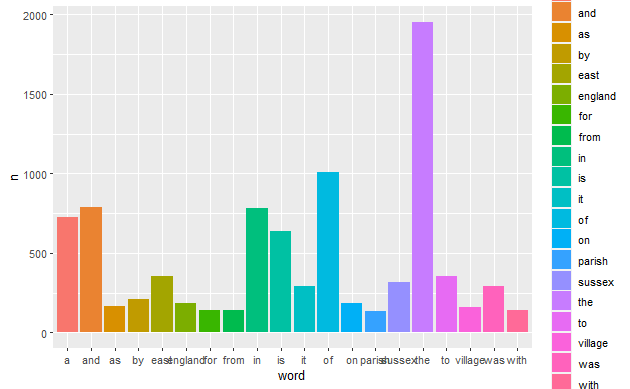

```r
ggplot(short_dataframe, aes(x = word, y = n, fill = word)) + geom_col()
```

###Clustering Using the latitude and longitude in the wiki_text the frequency of words are clustered into 6 different clusters. Each clusters contains the page_name which are geographically present near the same coordinates.

```r
kmeans <- wiki_text%>%
  dplyr::select(gt_lat,gt_lon)%>%
  stats::kmeans(centers = 6,iter.max = 50)

cluster <-
  wiki_text %>%
  tibble::add_column(
    cluster = kmeans%$% cluster%>% as.character()
  )
```

Filtering the cluster 3 and removing the stop words.

```r
cluster %>%
  filter(cluster == 3) %>%
  anti_join(stop_words) %>%
  count(word, sort = TRUE)
```

| word | n |
| --- | --- |
| forest | 57 |
| east | 48 |
| sussex | 32 |
| ashdown | 30 |
| village | 26 |
| england | 23 |
| miles | 22 |
| pooh | 22 |
| wood | 22 |
| station | 19 |

[output cut: 990 more lines]

Cluster_geo consists of columns with the page_name and words along with its respected clusters and its coordinates.

```r
cluster_geo <- cluster %>%
  sf::st_as_sf(coords = c('gt_lon', 'gt_lat'))
```

The plot cluster_geo displaying all the six clusters.

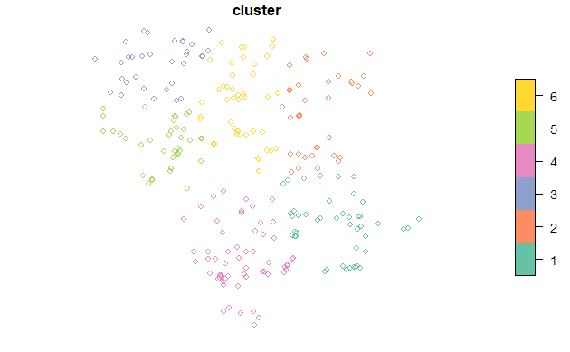

```r
plot(cluster_geo['cluster'])
```

freq_cluster displays the first 10 words without the stop words from all the clusters and its count.

```r
freq_cluster <- tibble(
  cluster = character(),
  word = character(),
  n = integer()
)

for (cluster_no in unique(cluster$cluster)){
  freq_cluster <- freq_cluster %>% rbind(
    cluster %>%
      filter(cluster == cluster_no) %>%
      anti_join(stop_words) %>%
      count(word, cluster, sort = TRUE) %>%
      slice_head(n = 10)
  )
}
```

Using the ggplot, the cluster 1 is filtered and plotted with words in X axis and number of counts in the Y axis.

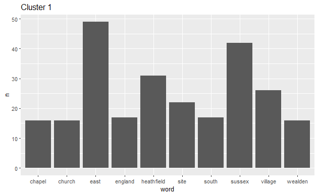

```r
freq_cluster %>% filter(cluster == '1') %>%
  ggplot() +
    geom_bar(aes(x = word, y = n), stat = 'identity')+
    labs(title = 'Cluster 1')
```

Using the ggplot, the cluster 2 is filtered and plotted with words in X axis and number of counts in the Y axis.

```r
freq_cluster %>% filter(cluster == '2') %>%
  ggplot() +
    geom_bar(aes(x = word, y = n), stat = 'identity')+
    labs(title = 'Cluster 2')
```

[output not shown]

Using the ggplot, the cluster 3 is filtered and plotted with words in X axis and number of counts in the Y axis.

```r
freq_cluster %>% filter(cluster == '3') %>%
  ggplot() +
    geom_bar(aes(x = word, y = n), stat = 'identity')+
    labs(title = 'Cluster 3')
```

[output not shown]

Using the ggplot, the cluster 4 is filtered and plotted with words in X axis and number of counts in the Y axis.

```r
freq_cluster %>% filter(cluster == '4') %>%
  ggplot() +
    geom_bar(aes(x = word, y = n), stat = 'identity')+
    labs(title = 'Cluster 4')
```

[output not shown]

Using the ggplot, the cluster 5 is filtered and plotted with words in X axis and number of counts in the Y axis.

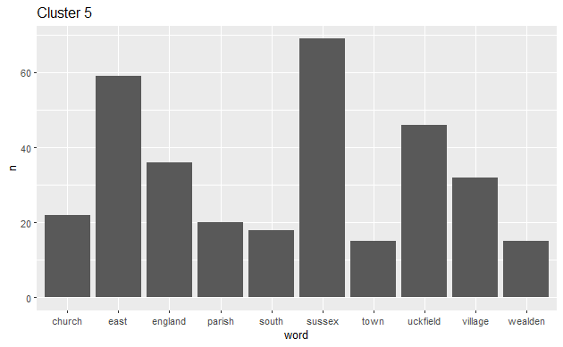

```r
freq_cluster %>% filter(cluster == '5') %>%
  ggplot() +
    geom_bar(aes(x = word, y = n), stat = 'identity')+
    labs(title = 'Cluster 5')
```

Using the ggplot, the cluster 6 is filtered and plotted with words in X axis and number of counts in the Y axis.

```r
freq_cluster %>% filter(cluster == '6') %>%
  ggplot() +
    geom_bar(aes(x = word, y = n), stat = 'identity') +
    labs(title = 'Cluster 6')
```

[output not shown]